# ANIMAL MODEL

Pierre-Alexandre QUITTET

2024-02-09

# **Packages**

```r
library(mgcv)  # GAM model
library(RODBC)  # connection to DBMS
library(tidyverse)
library(pedantics)
library(kinship2)
library(MCMCglmm)
library(mgcv)  # GAM model
library(latex2exp)
library(coda)  # bayesian
library(ggroups)  # generate dominance matrix
library(DHARMa)  # for residuals
library(ggdist)
library(gridExtra)  # display several ggplot
library(quantreg)
library(lme4)
library(MuMIn)
library(car)

source("C:/Users/p_a_8/Documents/GitHub/marmot-quantitative-genetics/1_DATA_ANALYSIS/1_MAIN_SCRIPTS/FUNCTIONS.R")
```

# **Data importation**

We import the data from the script ‘PHENOTYPE.R’.

# **MCMCglmm**

The output of the `MCMCglmm()` function include :

- `Sol` : Posterior Distribution of MME solutions, including fixed effects [posterior distribution of the **estimates** of fixed and random effects]
- `VCV` : Posterior Distribution of (co)variance matrices [posterior distribution of the **variances**]
- `CP` :Posterior Distribution of cut-points from an ordinal model
- `Liab` : Posterior Distribution of latent variables
- `Fixed` : list: fixed formula and number of fixed effects
- `Random` : list: random formula, dimensions of each covariance matrix, number of levels per covariance matrix, and term in random formula to which each covariance belongs
- `Residual` : list: residual formula, dimensions of each covariance matrix, number of levels per covariance matrix, and term in residual formula to which each covariance belongs
- `Deviance` : deviance -2*log(p(y|…))
- `DIC` : deviance information criterion
- `X` : sparse fixed effect design matrix
- `Z` : sparse random effect design matrix
- `XL`: sparse structural parameter design matrix
- `error.term` : residual term for each datum
- `family` : distribution of each datum
- `Tune` :(co)variance matrix of the proposal distribution for the latent variables
- `pl` : boolean (default : F), if sotrage of latent variables (e.g. $E[y]$) posterior distribution
- `pr` : boolean (default : F), if sotrage of the posterior distribution of random effects

NOTE : in `MCMCglmm` output, the `units` in the summary refers to the residuals.

# ______________________________________________

# **BIVARIATE**

```r
prior <- list(R = list(V = diag(2), nu = 2),  # prior for residual variance
              G = list(G1 = list(V = diag(2), nu = 2, alpha.mu = rep(0, 2), alpha.V = 1000*diag(2)),  # animal
                       G2 = list(V = diag(2), nu = 2, alpha.mu = rep(0, 2), alpha.V = 1000*diag(2)),  # cohort
                       G3 = list(V = diag(2), nu = 2, alpha.mu = rep(0, 2), alpha.V = 1000*diag(2))  # mother
              )
)
```

**Model**

```r
# META PARAMETERS
sample_size_goal <- 1000
burnin = 300000
thin = 5000
nitt = thin * sample_size_goal + burnin

paste0("Effective iteration : ", nitt)


data <- data_mcmc_biv_marmotton

# --- Remove cohort with < 3 observations
data <- data[!data$annee_emergence %in% c(1990:1996),]
data$annee_emergence <- factor(data$annee_emergence, levels = c(1997:2023))


# GAM FOR COHORT ----------------------------------------------------------
data[,"annee_emergence_gam"] <- as.numeric(as.character(data[,"annee_emergence"]))


# NORMALIZATION
data[,"annee_emergence_gam"]  = as.numeric(data[,"annee_emergence"]) - min(as.numeric(data[,"annee_emergence"]))
data[,"annee_emergence_gam"] <- data[,"annee_emergence_gam"] / max(data[,"annee_emergence_gam"])

# CUBIC SPLINES
n.knots <- 3
X <- cubic_spline(covariable = as.numeric(data[,"annee_emergence_gam"]), n.knots = n.knots)$X  # see FUNCTIONS.R for cubic_spline()

# MERGE X WITH DATA
data <- cbind(data, X)



# SCALE PREDICTORS --------------------------------------------------------
fixed_effects <- c("capture_time", "age_d", "litter_size_naissance", "taille_groupe_naissance", "inbreeding")

# --- Non GAM fixed effects
for(i in fixed_effects){
  data[,i] <- scale(data[,i], center = TRUE, scale = FALSE)
}

# --- GAM fixed effect [we scale them also as units does not matter]
gam__fixed_effects <- paste0("V", 2:(n.knots+2))

for(i in gam__fixed_effects){
  data[,i] <- scale(data[,i], center = TRUE, scale = TRUE)
}

# PRUNED PEDIGREE ---------------------------------------------------------
pedigree <- prunePed(pedigree = pedigree_data_biv_marmotton[1:3],
                     keep = data$individual_id,  # IDs of informative individual and descendant (i.e. with measures)
                     make.base = T)

# PRIOR DEFINITION --------------------------------------------------------
prior <- list(R = list(V = diag(2), nu = 2),  # prior for residual variance
              G = list(G1 = list(V = diag(2), nu = 2, alpha.mu = rep(0, 2), alpha.V = 1000*diag(2)),  # animal
                       G2 = list(V = diag(2), nu = 2, alpha.mu = rep(0, 2), alpha.V = 1000*diag(2)),  # anne_emergence
                       G3 = list(V = diag(2), nu = 2, alpha.mu = rep(0, 2), alpha.V = 1000*diag(2))  # mother
              )
)


# MODEL -------------------------------------------------------------------
mod_tibia_mcmc_13triv_1997 <- MCMCglmm(
  data = data,
  fixed = cbind(masse, tibia) ~
    (trait - 1) +
    at.level(trait, c("tibia", "masse")):capture_time+
    at.level(trait, c("tibia", "masse")):sexe +
    at.level(trait, c("tibia", "masse")):age_d +
    at.level(trait, c("tibia", "masse")):litter_size_naissance +
    at.level(trait, c("tibia", "masse")):taille_groupe_naissance +
    at.level(trait, c("tibia", "masse")):inbreeding +
    at.level(trait, c("tibia", "masse")):V2 +
    at.level(trait, c("tibia")):V3 +
    at.level(trait, c("tibia")):V4 +
    at.level(trait, c("tibia")):V5,

  random = ~ us(trait):animal + us(trait):annee_emergence + us(trait):mother,
  rcov = ~ us(trait):units,
  nitt = nitt,
  burnin = burnin,
  family = c("gaussian", "gaussian"),
  thin = thin,
  pedigree = pedigree,
  pr = T,  # get bv
  prior = prior,
  verbose = F
)
```

**Importation from cluster**  
.rds file computed in the *compute cluster*

```r
mod_result_name = c("mod13triv_1997", "mod13triv_P1_1997", "mod13triv_P2")

# Model results
for(i in mod_result_name){
    load(paste0("C:/Users/p_a_8/Documents/GitHub/marmot-quantitative-genetics/1_DATA_ANALYSIS/2_BILAN_ANALYSE_Rmarkdown/DATA_CLUSTER/TIBIA/", i, ".rds", collapse  = ""))
}


# load("C:/Users/p_a_8/Documents/GitHub/marmot-quantitative-genetics/1_DATA_ANALYSIS/2_BILAN_ANALYSE_Rmarkdown/DATA_CLUSTER/TIBIA/mod13biv3_no_cohort.rds")
```

```r
# MODEL RESULT FROM CLUSTER
mod_result <- get(paste0("mod_tibia_mcmc_", gsub(pattern = "mod", replacement = "", x = mod_result_name[1])))
mod_result_P1 <- get(paste0("mod_tibia_mcmc_", gsub(pattern = "mod", replacement = "", x = mod_result_name[2])))
mod_result_P2 <- get(paste0("mod_tibia_mcmc_", gsub(pattern = "mod", replacement = "", x = mod_result_name[3])))

# DATA USED TO MODELLING
data = data_mcmc_biv_marmotton
data_P1 = data_mcmc_biv_marmotton
data_P2 = data_mcmc_biv_marmotton

# # IF NO OUTLIERS
# rownames(data) <- 1:nrow(data)
# row.out <- unique(c(which(data$masse >= 700), which(data$tibia >= 65)))
#
# data <- data[-row.out,]
# data <- data[data$age_d <= 5, ]
data <- data[data$annee_emergence %in%  c(1997:2023),]
data$annee_emergence <- factor(data$annee_emergence, levels = c(1997:2023))

# --- Remove cohort with < 3 observations
# data <- data[!data$annee_emergence %in% c(1990, 1991, 1996),]
# data$annee_emergence <- factor(data$annee_emergence, levels = c(1992:1995, 1997:2023))


# # P1
data_P1 <- data_P1[data_P1$annee_emergence %in% c(1997:2005),]
data_P1$annee_emergence <- factor(data_P1$annee_emergence, levels = c(1997:2005))
#
# # # P2
data_P2 <- data_P2[data_P2$annee_emergence %in% c(2006:2023),]
data_P2$annee_emergence <- factor(data_P2$annee_emergence, levels = c(2006:2023))
```

### **Output**

#### **Autocorrelation and convergence**

```r
# AUTOCORRELATION OF CHAIN ITERATIONS
autocorr.diag(mod_result$VCV)
autocorr.diag(mod_result_P1$VCV)
autocorr.diag(mod_result_P2$VCV)


# CONVERGENCE TEST
heidel.diag(mod_result$VCV)
heidel.diag(mod_result_P1$VCV)
heidel.diag(mod_result_P2$VCV)
```

#### **Residuals**

```r
# plot_mcmc_residuals(mod_result = mod_result,
#                     data = data_mcmc_masse_marmotton,
#                     y = c(data_mcmc_masse_marmotton$masse, data_mcmc_masse_marmotton$tibia))
```

#### **Summary**

```r
summary(mod_result)
```

```
##
##  Iterations = 300001:5295001
##  Thinning interval  = 5000
##  Sample size  = 1000
##
##  DIC: 17587.39
##
##  G-structure:  ~us(trait):animal
##
##                              post.mean l-95% CI u-95% CI eff.samp
## traitmasse:traitmasse.animal  3803.910 2878.295 4727.465   1000.0
## traittibia:traitmasse.animal   153.863  111.643  198.510    911.9
## traitmasse:traittibia.animal   153.863  111.643  198.510    911.9
## traittibia:traittibia.animal     7.156    4.525    9.483   1000.0
##
##                ~us(trait):annee_emergence
##
##                                       post.mean l-95% CI u-95% CI eff.samp
## traitmasse:traitmasse.annee_emergence  1394.026 684.0680 2273.844     1000
## traittibia:traitmasse.annee_emergence    17.331  -6.3220   41.167     1000
## traitmasse:traittibia.annee_emergence    17.331  -6.3220   41.167     1000
## traittibia:traittibia.annee_emergence     1.856   0.6561    3.283     1000
##
##                ~us(trait):mother
##
##                              post.mean l-95% CI u-95% CI eff.samp
## traitmasse:traitmasse.mother  3376.713 2222.350 4773.945     1000
## traittibia:traitmasse.mother   111.699   68.188  156.898     1000
## traitmasse:traittibia.mother   111.699   68.188  156.898     1000
## traittibia:traittibia.mother     4.094    2.283    5.722     1000
##
##  R-structure:  ~us(trait):units
##
##                             post.mean l-95% CI u-95% CI eff.samp
## traitmasse:traitmasse.units  1156.364  730.642 1619.900   1000.0
## traittibia:traitmasse.units    39.376   16.606   60.878    907.7
## traitmasse:traittibia.units    39.376   16.606   60.878    907.7
## traittibia:traittibia.units     4.362    3.019    5.721   1000.0
##
##  Location effects: cbind(masse, tibia) ~ (trait - 1) + at.level(trait, c("tibia", "masse")):capture_time + at.level(trait, c("tibia", "masse")):sexe + at.level(trait, c("tibia", "masse")):age_d + at.level(trait, c("tibia", "masse")):litter_size_naissance + at.level(trait, c("tibia", "masse")):tai…
```

[output cut: 88 more lines]

```
## at.level(trait, c("tibia", "masse"))1:age_d                   ***
## at.level(trait, c("tibia", "masse"))2:age_d                   ***
## at.level(trait, c("tibia", "masse"))1:litter_size_naissance   ***
## at.level(trait, c("tibia", "masse"))2:litter_size_naissance   ***
## at.level(trait, c("tibia", "masse"))1:taille_groupe_naissance ***
## at.level(trait, c("tibia", "masse"))2:taille_groupe_naissance ***
## at.level(trait, c("tibia", "masse"))1:inbreeding
## at.level(trait, c("tibia", "masse"))2:inbreeding
## at.level(trait, c("tibia", "masse"))1:V2                      ***
## at.level(trait, c("tibia", "masse"))2:V2
## at.level(trait, c("tibia")):V3                                ***
## at.level(trait, c("tibia")):V4                                **
## at.level(trait, c("tibia")):V5                                **
## ---
## Signif. codes:  0 '***' 0.001 '**' 0.01 '*' 0.05 '.' 0.1 ' ' 1
```

#### **Posterior**

```r
plot(mod_result$VCV)
```

#### **Genetic parameters**

**Genetic correlation**

```r
cor.gen <- mod_result$VCV[,"traitmasse:traittibia.animal"] / sqrt(mod_result$VCV[,"traitmasse:traitmasse.animal"] * mod_result$VCV[,"traittibia:traittibia.animal"])

mean <- round(mean(cor.gen), 3)
ic <- round(HPDinterval(cor.gen), 3)
```

[output not shown]

**Genetic parameters**

```r
# mod_result = mod_result
# position = "mean"  # function used to compute genetic parameters
# decimal = 2
# trait = c("masse", "tibia")

# Pooled
compute_stats_re_bivariate(mod_result = mod_result,
                           position = "mean",  # function used to compute genetic parameters
                           decimal = 2,
                           trait = c("masse", "tibia")
                           )
```

```
## $variance
##             animal  cohort  mother   units      vf
## masse_y    3803.91 1394.03 3376.71 1156.36 3404.61
## masse_ymin 2878.30  684.07 2222.35  730.64 2632.48
## masse_ymax 4727.46 2273.84 4773.94 1619.90 4184.54
## tibia_y       7.16    1.86    4.09    4.36   10.11
## tibia_ymin    4.53    0.66    2.28    3.02    7.99
## tibia_ymax    9.48    3.28    5.72    5.72   12.57
##
## $ratio
##            animal cohort mother units   vf
## masse_y      0.29   0.11   0.26  0.09 0.26
## masse_ymin   0.22   0.06   0.18  0.05 0.21
## masse_ymax   0.36   0.17   0.33  0.13 0.32
## tibia_y      0.26   0.07   0.15  0.16 0.37
## tibia_ymin   0.18   0.03   0.09  0.10 0.30
## tibia_ymax   0.34   0.11   0.20  0.22 0.43
```

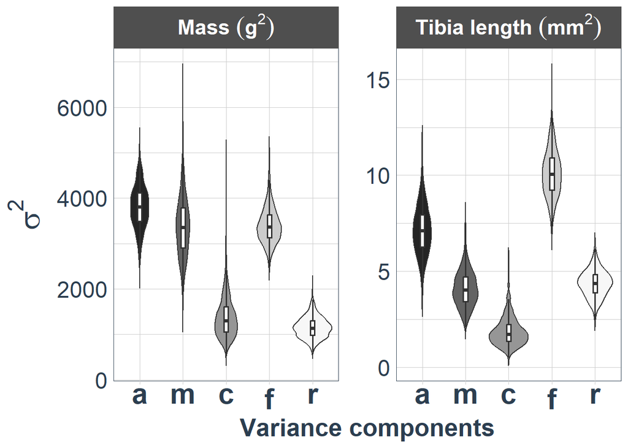

```r
# VISUALISATION
compute_stats_re_bivariate_violin_plot(mod_result = mod_result,
                           type = "variance",
                           trait = c("masse", "tibia"),
                           ylim = NULL
                           )
```

**Coefficient of variation**

```r
# FUNCTION
coef_var <- function(trait = "tibia", variance, data = data_mcmc_biv_marmotton, title = NULL){
  cat("\n ==========", title ,"============ \n ")
  mean_trait <- mean(data[,trait], na.rm = T)
  cv <- round(100 * mean(sqrt(variance) / mean_trait), 2)
  cv_lwr <- round(HPDinterval(100 *sqrt(variance) / mean_trait)[1], 2)
  cv_upr <- round(HPDinterval(100 *sqrt(variance) / mean_trait)[2], 2)

  return(cat(trait, " : ", cv, " [",cv_lwr, "; ", cv_upr, "]\n"))
}


# --- Additive
coef_var(trait = "tibia", variance = mod_result$VCV[, paste0("trait", "tibia", ":trait", "tibia", ".animal")], title = "Additive")
```

```
##
##  ========== Additive ============
##  tibia  :  5.08  [ 4.23 ;  6.02 ]
```

```r
coef_var(trait = "masse", variance = mod_result$VCV[, paste0("trait", "masse", ":trait", "masse", ".animal")], title = "Additive")
```

```
##
##  ========== Additive ============
##  masse  :  16.02  [ 14.23 ;  18.16 ]
```

```r
# --- Maternal
coef_var(trait = "tibia", variance = mod_result$VCV[, paste0("trait", "tibia", ":trait", "tibia", ".mother")], title = "Mother")
```

```
##
##  ========== Mother ============
##  tibia  :  3.84  [ 2.97 ;  4.64 ]
```

```r
coef_var(trait = "masse", variance = mod_result$VCV[, paste0("trait", "masse", ":trait", "masse", ".mother")], title = "Mother")
```

```
##
##  ========== Mother ============
##  masse  :  15.05  [ 12.27 ;  17.99 ]
```

```r
# --- Cohort
coef_var(trait = "tibia", variance = mod_result$VCV[, paste0("trait", "tibia", ":trait", "tibia", ".annee_emergence")], title = "Cohort")
```

```
##
##  ========== Cohort ============
##  tibia  :  2.55  [ 1.8 ;  3.69 ]
```

```r
coef_var(trait = "masse", variance = mod_result$VCV[, paste0("trait", "masse", ":trait", "masse", ".annee_emergence")], title = "Cohort")
```

```
##
##  ========== Cohort ============
##  masse  :  9.59  [ 7.08 ;  12.66 ]
```

```r
# --- Residuals
coef_var(trait = "tibia", variance = mod_result$VCV[, paste0("trait", "tibia", ":trait", "tibia", ".units")], title = "Residuals")
```

```
##
##  ========== Residuals ============
##  tibia  :  3.97  [ 3.33 ;  4.58 ]
```

```r
coef_var(trait = "masse", variance = mod_result$VCV[, paste0("trait", "masse", ":trait", "masse", ".units")], title = "Residuals")
```

```
##
##  ========== Residuals ============
##  masse  :  8.81  [ 7.19 ;  10.61 ]
```

#### **Phenotypic temporal variation**

#### **Breeding values**

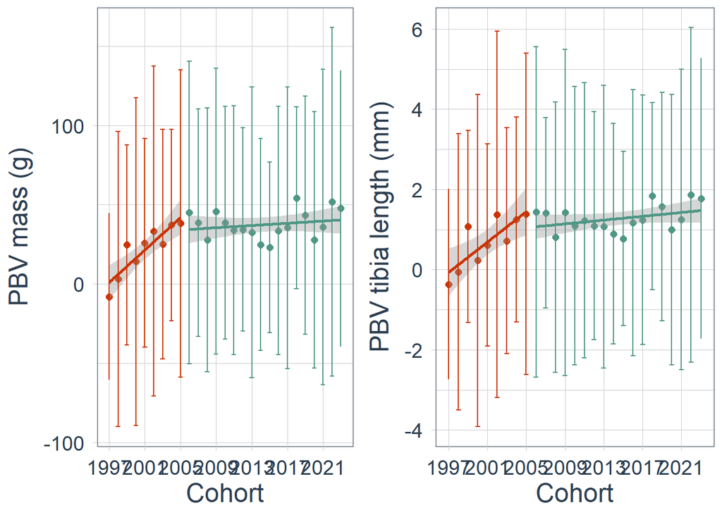

```r
# mod_result = mod_result
# data = data
# position = "mean"
# trait = c("masse", "tibia")
# method_regression = "lm"
# periode = list(c(1997:2023), 1997:2023)
# main = NULL

plot_breeding_values(mod_result = mod_result,
                               data = data,
                               position = "mean",
                               trait = c("masse", "tibia"),
                               method_regression = "lm",
                               periode = list(c(1997:2023), 1997:2023),
                               main = NULL,
                               color_period = c("#cc3300", "#4e9785")
                               )
```

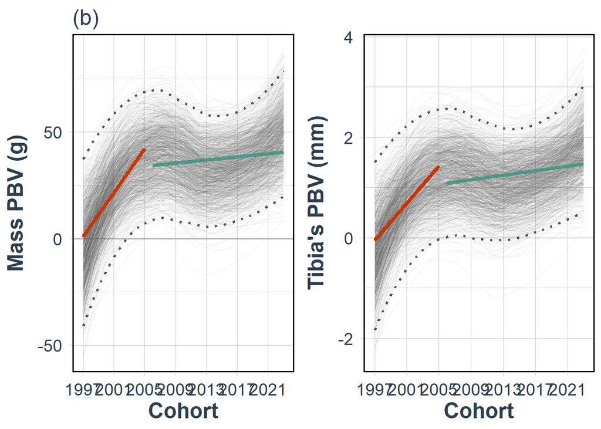

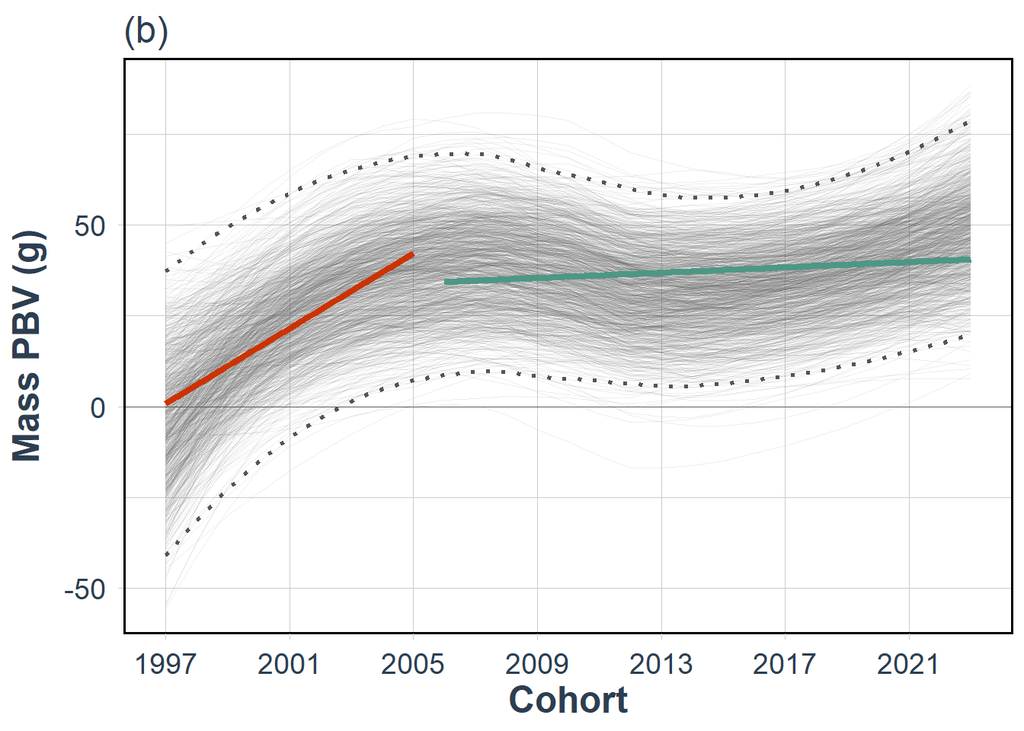

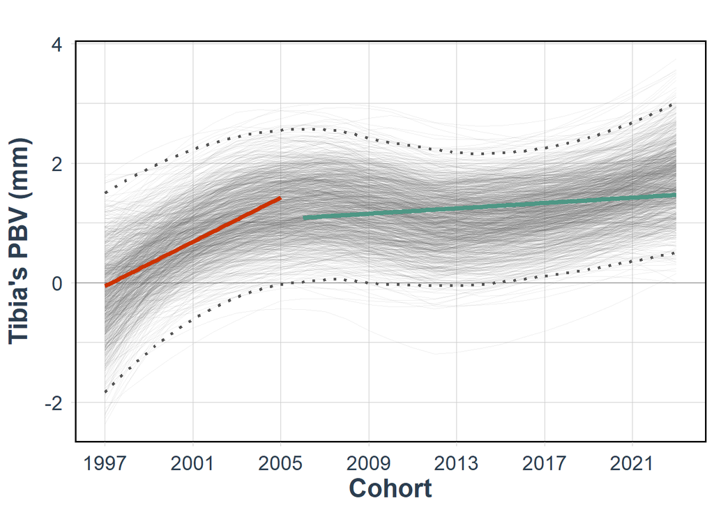

```r
plot_breeding_values_posterior(mod_result = mod_result,
                               data = data,
                               trait = c("masse", "tibia"))
```

```r
# PLOT WITH PHENOTYPIC TREND
# gridExtra::grid.arrange(plot_mass_gam, plot_gam_tibia, plot_BV$plot_masse, plot_BV$plot_tibia, ncol = 2, nrow = 2)
```

**Pedigree pruning**

```r
# PRUNED PEDIGREE USED FOR MODELING
pedigree <- prunePed(pedigree = pedigree_data_biv_marmotton[1:3],
                     keep = data$individual_id,  # IDs of informative individual and descendant (i.e. with measures)
                     make.base = T)
```

**DRIFT** For each iteration of the MCMC, we compute the mean predicted breeding values (EPB) alongside the slope of EPB as a function of cohorts and compare it with drift.

```r
set.seed = 2312
drift <- test_drift(mod_result = mod_result,
           pedigree = pedigree,
           position = "mean",
           periode_pooled_tibia = 1997:2023,
           periode_pooled_masse =  c(1997:2023),
           periode1_tibia = 1997:2005,
           periode2_tibia = 2006:2023,
           periode1_masse = c(1997:2005),
           periode2_masse = 2006:2023,
           trait = c("masse", "tibia"),
           iteration = 1000,
            color_period = c("#36465d", "#cc3300", "#4e9785"))
```

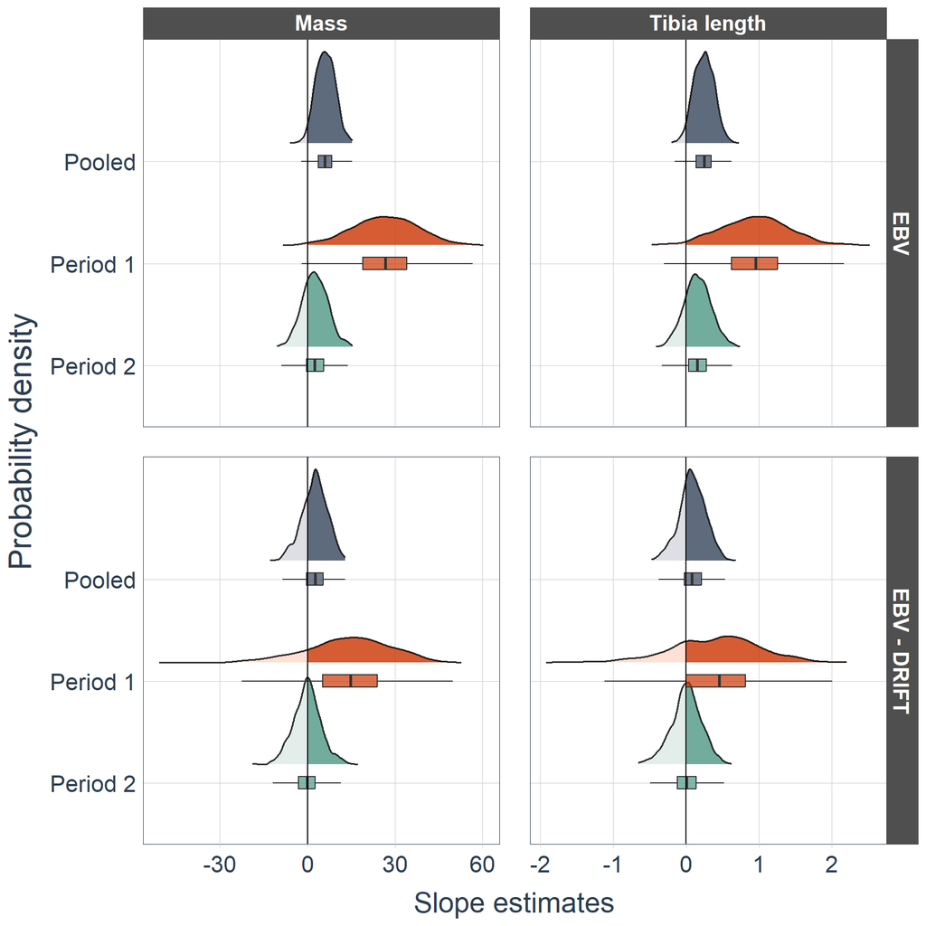

```r
drift$sign_evolution_p_values
```

```
##                  masse tibia
## post_df          0.029 0.032
## post_df_periode1 0.006 0.021
## post_df_periode2 0.280 0.187
```

```r
drift$drift_p_values
```

```
##                  masse tibia
## post_df          0.150 0.163
## post_df_periode1 0.085 0.127
## post_df_periode2 0.385 0.312
```

```r
drift$df_stats
```

```
##                     ebv_masse          ebv_drift_masse            delta_masse
## Pooled  6.038 [0.835; 11.303]    0.236 [-8.228; 7.937]  2.644 [-5.647; 9.158]
## P1     26.744 [8.143; 44.431] -0.817 [-26.188; 25.494] 14.8 [-11.853; 36.267]
## P2       2.521 [-4.53; 9.604]     0.124 [-9.46; 9.899] -0.055 [-7.994; 7.806]
##                    ebv_tibia        ebv_drift_tibia           delta_tibia
## Pooled  0.249 [0.021; 0.473] -0.005 [-0.342; 0.345] 0.086 [-0.228; 0.388]
## P1      0.957 [0.176; 1.692]  -0.02 [-1.167; 1.125] 0.459 [-0.701; 1.435]
## P2     0.155 [-0.147; 0.476] -0.001 [-0.435; 0.451] 0.013 [-0.363; 0.335]
```

# ______________________________________________

# **SELECTION MODEL**

## **Model FITNESS (PUPS)** ____________

```r
# META PARAMETERS
sample_size_goal <- 1000
burnin = 300000
thin = 6000
nitt = thin * sample_size_goal + burnin

paste0("Effective iteration : ", nitt)


# DATA USED
data <- data_mcmc_biv_marmotton

# SELECT COHORT FOR WHICH FITNESS CAN BE CALCULATED -----------------------
# AGE THRESHOLD DETERMINED PREVIOUSLY FROM WHICH WE CONSIDER THE COHORT IS EXTINCT
age_threshold <- 7
data <- data[!data$annee_emergence %in% c(1990, 1991, 1996, (2023-age_threshold + 1):2023),]
data$annee_emergence <- factor(data$annee_emergence, levels = c(1992:1995, 1997:(2023-age_threshold)))




# COMPUTE FITNESS ---------------------------------------------------------
pheno <- pheno[!duplicated(pheno$individual_id),]  # only non repeated individual of the whole dataset
mean_cohort_LRS <- tapply(pheno$LRS, pheno$annee_emergence, function(x) mean(x, na.rm = T))  # get mean LRS per cohort
index <- match(data$annee_emergence, names(mean_cohort_LRS))  # get index to divide LRS of dataset with associated cohort LRS mean
data["LRS_relative"] <- data$LRS / mean_cohort_LRS[index]



# GAM FOR COHORT ----------------------------------------------------------
# CONVERT VI TO NUMERIC
data[,"annee_emergence_gam"] <- as.numeric(as.character(data[,"annee_emergence"]))


# NORMALIZATION
data[,"annee_emergence_gam"]  = as.numeric(data[,"annee_emergence"]) - min(as.numeric(data[,"annee_emergence"]))
data[,"annee_emergence_gam"] <- data[,"annee_emergence_gam"] / max(data[,"annee_emergence_gam"])

# CUBIC SPLINES
n.knots <- 3
X <- cubic_spline(covariable = as.numeric(data[,"annee_emergence_gam"]), n.knots = n.knots)$X

# MERGE X WITH DATA
data <- cbind(data, X)


# SCALE PREDICTORS --------------------------------------------------------
fixed_effects <- c("capture_time", "age_d", "litter_size_naissance", "taille_groupe_naissance", "inbreeding")

# --- Non GAM fixed effects
for(i in fixed_effects){
  data[,i] <- scale(data[,i], center = TRUE, scale = FALSE)
}

# --- GAM fixed effect [we scale them also as units does not matter]
gam__fixed_effects <- paste0("V", 2:(n.knots + 2))

for(i in gam__fixed_effects){
  data[,i] <- scale(data[,i], center = TRUE, scale = TRUE)
}


# PRUNED PEDIGREE ---------------------------------------------------------
pedigree <- prunePed(pedigree = pedigree_data_biv_marmotton[1:3],
                     keep = data$individual_id,  # IDs of informative individual and descendant (i.e. with measures)
                     make.base = T)


# PRIOR DEFINITION --------------------------------------------------------
prior <- list(R = list(V = diag(3), nu = 3),  # prior for residual variance
              G = list(G1 = list(V = diag(3), nu = 3, alpha.mu = rep(0, 3), alpha.V = 1000*diag(3)),  # animal
                       G2 = list(V = diag(2), nu = 2, alpha.mu = rep(0, 2), alpha.V = 1000*diag(2)),  # annee_emergence
                       G3 = list(V = diag(3), nu = 3, alpha.mu = rep(0, 3), alpha.V = 1000*diag(3))  # mother
              )
)


# MODEL -------------------------------------------------------------------
mod_tibia_mcmc_13triv_fitness <- MCMCglmm(
  data = data,
  fixed = cbind(tibia, masse, LRS_relative) ~
    (trait - 1) +
    at.level(trait, c("tibia", "masse")):capture_time+
    at.level(trait, c("tibia", "masse")):sexe +
    at.level(trait, c("tibia", "masse")):age_d +
    at.level(trait, c("tibia", "masse")):litter_size_naissance +
    at.level(trait, c("tibia", "masse")):taille_groupe_naissance +
    at.level(trait, c("tibia", "masse")):inbreeding +
    at.level(trait, c("tibia", "masse")):V2 +
    at.level(trait, c("tibia")):V3 +
    at.level(trait, c("tibia")):V4 +
    at.level(trait, c("tibia")):V5,

  random = ~ us(trait):animal + us(at.level(trait, c("tibia", "masse"))):annee_emergence + us(trait):mother,
  rcov = ~ us(trait):units,
  nitt = nitt,
  burnin = burnin,
  family = c("gaussian", "gaussian", "gaussian"),
  thin = thin,
  pedigree = pedigree,
  pr = T,  # get bv
  prior = prior,
  verbose = F
)

# SAVE RESULTS
save(mod_tibia_mcmc_13triv_fitness, file = "~/TIBIA/SORTIE_MODELES/mod13triv_fitness.rds")
```

**Importation from cluster**  
.rds file computed in the *compute cluster*

```r
# MODEL RESULT FROM CLUSTER
# --- Without random effect
mod_result_fitness_pheno <- mod_tibia_mcmc_13triv_fitness_1997_pheno  #pooled
mod_result_P1_pheno <- mod_tibia_mcmc_13triv_fitness_P1_1997_pheno  # P1
mod_result_P2_pheno <- mod_tibia_mcmc_13triv_fitness_P2_pheno  # P2
# --- With random effect
mod_result_fitness <- mod_tibia_mcmc_13triv_fitness_1997  #pooled
mod_result_P1 <- mod_tibia_mcmc_13triv_fitness_P1_1997  # P1
mod_result_P2 <- mod_tibia_mcmc_13triv_fitness_P2  # P2
# mod_result_norm <- mod_tibia_mcmc_13triv_fitness_norm  #pooled
# mod_result_P1_norm <- mod_tibia_mcmc_13triv_fitness_P1_norm  # P1
# mod_result_P2_norm <- mod_tibia_mcmc_13triv_fitness_P2_norm  # P2
# mod_result_tibia <- mod_tibia_mcmc_13biv_tibia_fitness
# mod_result_tibia_P1 <- mod_tibia_mcmc_13biv_tibia_fitness_P1
# mod_result_tibia_P2 <- mod_tibia_mcmc_13biv_tibia_fitness_P2
# mod_result_masse <- mod_tibia_mcmc_13biv_masse_fitness
# mod_result_masse_P1 <- mod_tibia_mcmc_13biv_masse_fitness_P1
# mod_result_masse_P2 <- mod_tibia_mcmc_13biv_masse_fitness_P2


# DATA USED TO MODELLING
data = data_mcmc_biv_marmotton


# POOLED
age_threshold <- 7
data <- data[data$annee_emergence %in% c(1997:(2023-age_threshold)),]
data$annee_emergence <- factor(data$annee_emergence, levels = c(1997:(2023-age_threshold)))


# P1
data = data_mcmc_biv_marmotton
data1 <- data[data$annee_emergence %in% c(1997:2005),]
data1$annee_emergence <- factor(data1$annee_emergence, levels = c(1997:2005))

# P2
data = data_mcmc_biv_marmotton
age_threshold <- 7
data2 <- data[data$annee_emergence %in% c(2006:(2023-age_threshold)),]
data2$annee_emergence <- factor(data2$annee_emergence, levels = c(2006:(2023-age_threshold)))



# COMPUTE FITNESS ---------------------------------------------------------
pheno <- pheno[!duplicated(pheno$individual_id),]  # only non repeated individual of the whole dataset
mean_cohort_LRS <- tapply(pheno$LRS, pheno$annee_emergence, function(x) mean(x, na.rm = T))  # get mean LRS per cohort

# --- pooled
index <- match(data$annee_emergence, names(mean_cohort_LRS))  # get index to divide LRS of dataset with associated cohort LRS mean
data["LRS_relative"] <- data$LRS / mean_cohort_LRS[index]

# --- P1
index <- match(data1$annee_emergence, names(mean_cohort_LRS))  # get index to divide LRS of dataset with associated cohort LRS mean
data1["LRS_relative"] <- data1$LRS / mean_cohort_LRS[index]

# --- P2
index <- match(data2$annee_emergence, names(mean_cohort_LRS))  # get index to divide LRS of dataset with associated cohort LRS mean
data2["LRS_relative"] <- data2$LRS / mean_cohort_LRS[index]
```

#### **Autocorrelation and convergence**

```r
# AUTOCORRELATION OF CHAIN ITERATIONS
autocorr.diag(mod_result_fitness$VCV)

# CONVERGENCE TEST
heidel.diag(mod_result_fitness$VCV)  # random effect
heidel.diag(mod_result_P1$VCV)  # random effect
heidel.diag(mod_result_P2$VCV)  # random effect
```

```r
summary(mod_result_fitness)
summary(mod_result_P1)
summary(mod_result_P2)
```

```r
plot(mod_result$VCV)
```